# A sample report

Elsa Fogelström

13 November 2018

# A markdown example with *Iris* data

## Background

This text is copy-pasted from the [Iris flower data set Wikipedia site](https://en.wikipedia.org/wiki/Iris_flower_data_set)

The Iris flower data set or Fisher’s *Iris* data set is a multivariate data set introduced by the British statistician and biologist Ronald Fisher in his 1936 paper The use of multiple measurements in taxonomic problems as an example of linear discriminant analysis. It is sometimes called Anderson’s *Iris* data set because Edgar Anderson collected the data to quantify the morphologic variation of *Iris* flowers of three related species. Two of the three species were collected in the Gaspé Peninsula “all from the same pasture, and picked on the same day and measured at the same time by the same person with the same apparatus”.

The data set consists of 50 samples from each of three species of *Iris* (*Iris setosa*, *Iris virginica* and *Iris versicolor*). Four features were measured from each sample: the length and the width of the sepals and petals, in centimetres. Based on the combination of these four features, Fisher developed a linear discriminant model to distinguish the species from each other.

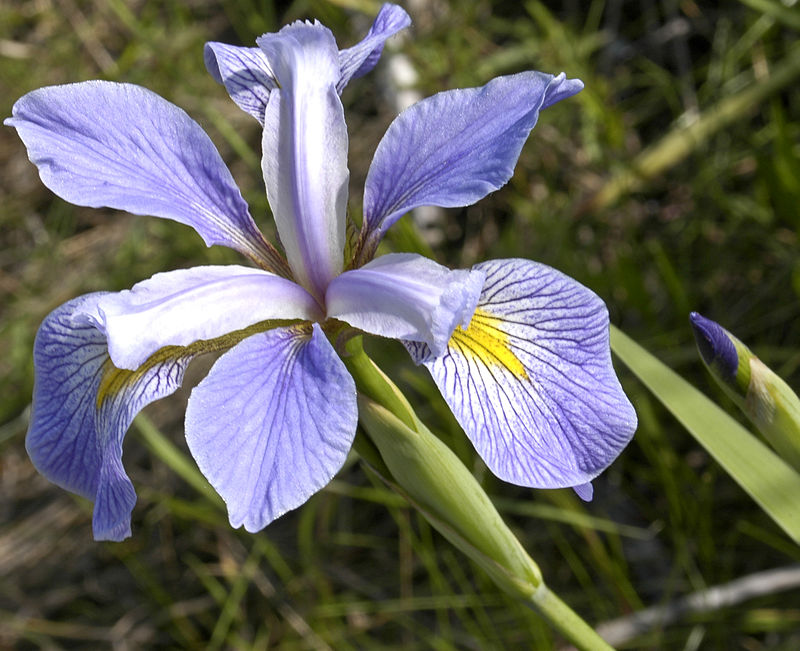

*Iris virginica*

## Summary statistics

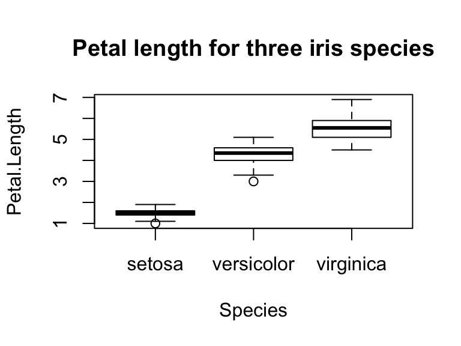

## Data analysis

I investigated whether petal lenght differed among the three *Iris* species with an ANOVA unsing the function `lm` in the package `base`.

|  | Df | Sum Sq | Mean Sq | F value | Pr(>F) |
| --- | --- | --- | --- | --- | --- |
| Species | 2 | 437.103 | 218.551 | 1180.161 | 0 |
| Residuals | 147 | 27.223 | 0.185 | NA | NA |